# The Squirrel Census

Luana Rossi & Nick Schneeberger

2023-02-18

#### 🐿️ 🌳 Come along on a journey to explore the mysterious world of Central Park’s squirrel population!

As we set out on our quest to uncover the optimal locations and weather conditions for observing Central Park’s squirrel population, we found ourselves asking two key questions: where are the squirrels most likely to be spotted, and how does the weather affect their behavior?

To answer the first question, we explored the hectare-by-hectare distribution of squirrel sightings throughout the park. Our data analysis revealed that certain areas of the park are more conducive to squirrel sightings than others. In fact, we discovered that one particular hectare had the highest frequency of squirrel sightings, making it the best location to visit for any aspiring squirrel watcher.

Next, we turned our attention to the weather. Could the temperature, precipitation, or time of day affect squirrel behavior and, therefore, their visibility to park-goers? Through our statistical analysis, we were able to identify specific weather conditions that are correlated with higher rates of squirrel sightings. Without giving away too much, we can say that certain temperatures and shifts in weather patterns seem to be particularly conducive to spotting squirrels.

As our investigation drew to a close, we couldn’t help but feel a sense of awe at the intricate dance between the squirrels and their environment. We hope that our findings will not only help visitors to Central Park have a more enjoyable and fruitful squirrel-watching experience, but also contribute to our collective understanding of these fascinating creatures and their role in the natural world.

# 📋 Datasets

In order to answer our research question, we’ve been working with data from “The Squirrel Census”. The squirrel census was a multimedia science project focusing on the Eastern gray (Sciurus carolinensis) squirrel in Central Park in New York City. It was conducted in October 2018, with the help of 323 volunteer Squirrel Sighters.

We’ve been working with the following two datasets from The Squirrel Census:

#### 🐿️ Squirrel Data

Dataset: 2018_Central_Park_Squirrel_Census_-_Squirrel_Data.csv

This table contains squirrel data for each of the 3,023 sightings, including location coordinates, age, primary and secondary fur color, elevation, activities, communications, and interactions between squirrels and with humans.

#### 📍 Hectare Data

Dataset: 2018_Central_Park_Squirrel_Census_-_Hectare_Data.csv

This table contains environmental data related to each of the 350 “countable” hectares of Central Park. Examples include weather, litter, animals sighted, and human density.

# 🧹 Cleaning and preparing the Data

Squirrel Sighters recorded temperature and weather conditions during their observations in a loosely structured comma-separated list. To process this weather data, we identified the most frequently occurring weather conditions and extracted the temperature values. To accomplish this, we firstly converted the list to lowercase and analyzed the recorded data.

Here is an example of how weather data was recorded by Squirrel Sighters:

```r
weather <- tolower(hectare$Sighter.Observed.Weather.Data)
head(weather)
```

```
## [1] "70º f, foggy"                 "54º f, overcast"
## [3] "60º f, sunny"                 "59.8º f, sun, cool"
## [5] "55° f, partly cloudy"         "66º f, cloudy, light drizzle"
```

## 🌡️ Extracting Temperature

Since temperature values were typically the only numerical data in the recorded list, we extracted them from the string using a regular expression (regex). Furthermore, we converted the temperature values from Fahrenheit to Celsius to ensure consistency across our analyses. The extracted and converted temperature data, we put into a new column.

```r
library(stringr)

# find temperature with regex
temp_fahrenheit <- as.numeric(str_extract(weather, "\\d+"))


# define function to convert from F to C
fahrenheit_to_celsius <- function(x) {
  if(!is.na(x)){
    (x - 32) * 5/9
  } else {
    NA
  }
}

# convert to celsius and then round to one decimal
temp_celsius <- round(sapply(temp_fahrenheit, fahrenheit_to_celsius), 1)

# add column to file
hectare$temperature_celsius <- temp_celsius
```

## 🌧️ Extracting Weather Conditions

We wanted to find out the weather conditions that were most commonly reported in our dataset. To do this, we separated the weather descriptions in the recorded list by splitting them at the commas.

```r
weather_split <- str_split(weather, ",")
```

We then counted the number of occurrences for each weather condition in our dataset.

```r
unique_weather <- str_trim(unique(unlist(weather_split)))
weather_no_numbers <- str_trim(unlist(weather_split), side = "both")[!str_detect(str_trim(unlist(weather_split), side = "both"), "\\d")]
top_10 <- sort(table(weather_no_numbers), decreasing = TRUE)[1:10]
top_10
```

```
## weather_no_numbers
##         sunny        cloudy      overcast partly cloudy         windy
##           136           109            66            54            48
##         clear        breezy         misty         humid          cool
##            34            32            29            22            20
```

Based on the weather conditions that appeared most frequently in our dataset, we created distinct groups of weather conditions. We carefully scanned the entire dataset for synonyms and categorized all weather conditions as follows:

| Weather Category | Adjectives |
| --- | --- |
| Sun | sunny, clear, bright, blue, pleasant, perfect, not a cloud, nice, fair, crisp |
| Clouds | overcast, cloudy, dreary, gray, not a cloud |
| Drizzle | light rain, drizzle, drizzling, drizzly, sprinkling, lite rain, couple drops of rain, a few raindrops |
| Rain | rain, rainy, wet, showers, heavy rain, pouring, drenching, torrential, downpour, cloudburst |
| Wind | windy, breezy, brisk, gusty |
| Fog | foggy, misty |
| Humid | humid, muggy, damp, moist |

These categories and adjectives were not suitable for our analysis:

| Weather Category | Adjectives |
| --- | --- |
| Temperature | cool, chilly, cold, warm, dewy, dewpoint, mild |
| Other | artsy lighting, got dark very suddenly, shady, sun starting to go down |
| No Wind | calm, no wind |

Subsequently, we developed a function to check each row of the hectare-dataset for the presence of the specific weather-adjectives from the table above. If a condition was found in a given row, we assigned a value of “true” to the corresponding (new) column. If not, we assigned a value of “false” to the same column. We repeated this process for all weather conditions of interest, creating a new column with a boolean value for each condition.

For illustrative purposes, below one example of this process applied to the “sunny” weather condition:

```r
detect_weather <- function(x, words_positive, words_negative = character(0)) {
  detect <- any(str_detect(x, paste(words_positive, collapse = "|")))
  if (detect == TRUE && length(words_negative) > 0) {
    not_detect <- any(str_detect(x, paste(words_negative, collapse = "|")))
    if (not_detect == TRUE) {
      detect <- FALSE
    }
  }
  detect
}

words_sun <- c("sun", "clear", "bright", "blue", "pleasant", "perfect", "not a cloud", "nice", "fair", "crisp")

sunny <- sapply(weather_split, function(x) detect_weather(x, words_sun))
sunny[1:10]
```

```
##  [1] FALSE FALSE  TRUE  TRUE FALSE FALSE FALSE FALSE  TRUE  TRUE
```

# 📊 Data Analysis

```r
weather <- read.csv("hectare_weather.csv")
squirrels <- read.csv("joint_squirrels.csv")
hectare <- read.csv("2018_Central_Park_Squirrel_Census_-_Hectare_Grid.csv")
```

### Number of Squirrel Sighting per Hectare

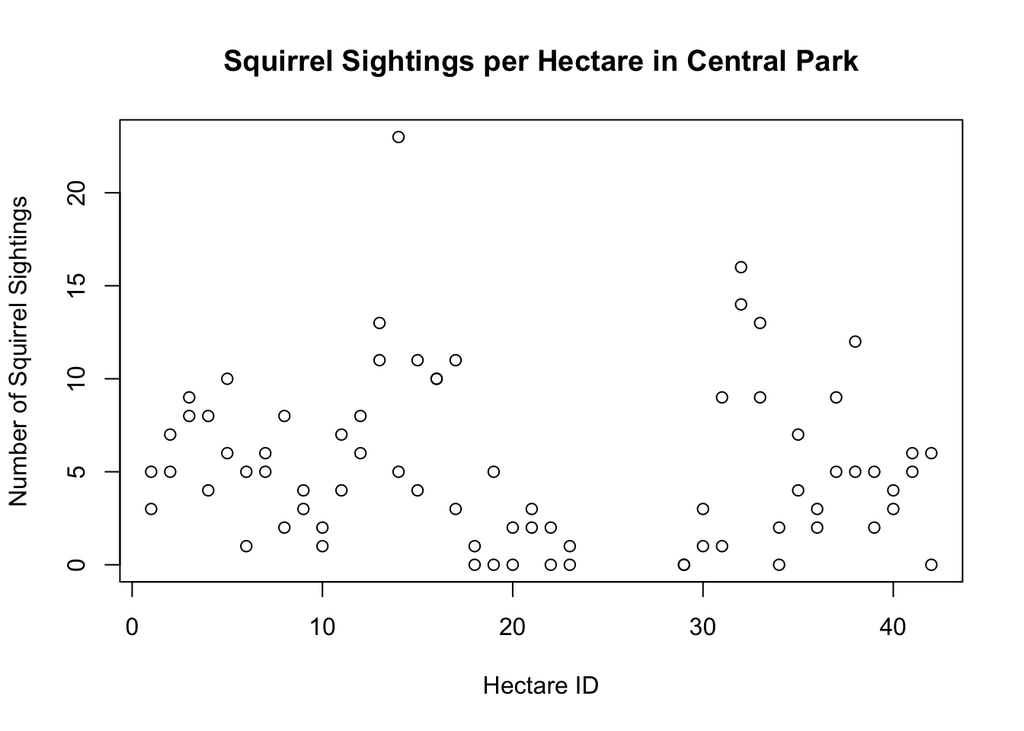

```r
plot(weather$Hectare, weather$Number.of.Squirrels,
     xlab="Hectare ID",
     ylab="Number of Squirrel Sightings",
     main="Squirrel Sightings per Hectare in Central Park")
```

### Squirrel Density by Hectare

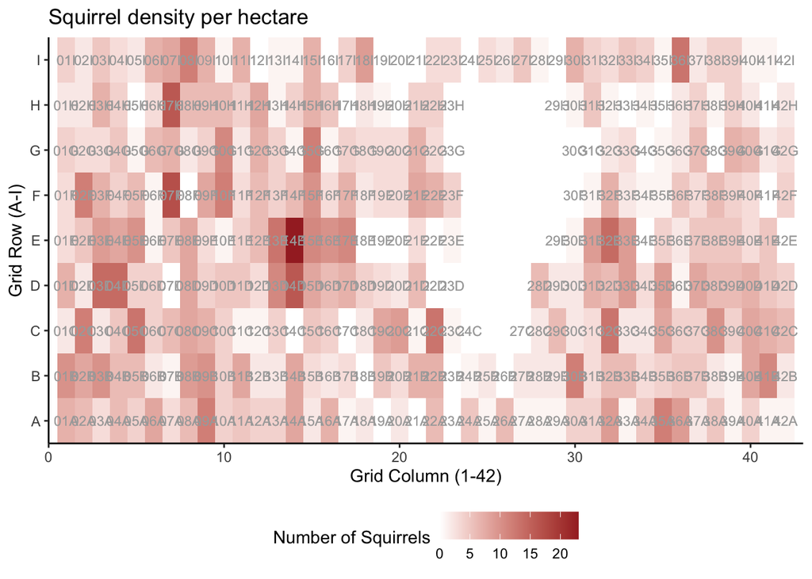

```r
library(ggplot2)

# Heatmap with squirrels per hectare in central park
ggplot(data = weather, cache = TRUE, aes(x = as.numeric(substr(Hectare, 1, 2)),
                           y = as.factor(substr(Hectare, 3, 3)),
                           fill = Number.of.Squirrels)) +
  geom_tile() +
  geom_text(aes(label = Hectare), color = "darkgrey", size = 3, vjust = 0.5) +
  scale_fill_gradient(low = "white", high = "brown") +
  scale_x_continuous(limits = c(0, 43), expand = c(0, 0)) +
  scale_y_discrete(limits = c("A", "B", "C", "D", "E", "F", "G", "H", "I"), expand = c(0, 0)) +
  labs(x = "Grid Column (1-42)", y = "Grid Row (A-I)", fill = "Number of Squirrels") +
  theme_classic() +
  ggtitle("Squirrel density per hectare") +
  theme(legend.position = "bottom")
```

# 🗺️ Squirrel Map from Geodata (chapter of choice)

First we set the bounding box (= frame) of our map, then we draw the map using ggmap()

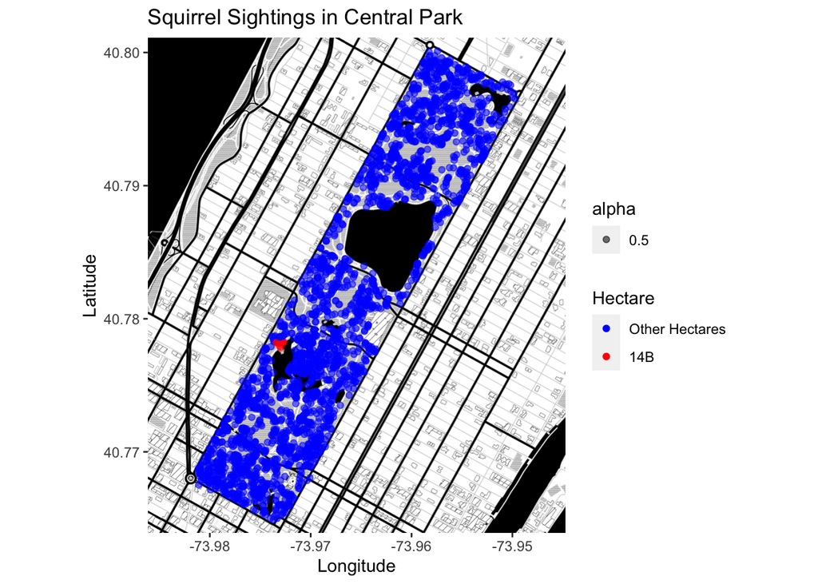

```r
longitude_min <- min(squirrels$X) - 0.005
latitude_min <- min(squirrels$Y) - 0.001
longitude_max <- max(squirrels$X) + 0.005
latitude_max <- max(squirrels$Y) + 0.001

# Background map
mad_map <- get_map(location = c(left = longitude_min, bottom = latitude_min, right = longitude_max, top = latitude_max),
                   source = "stamen",
                   maptype = "toner-background",
                   zoom = 15,
                   cache = TRUE)
d.stations <- data.frame(Latitude = squirrels$Y,
                         Longitude = squirrels$X)

ggmap(mad_map) +
  geom_point(data = squirrels,
             aes(x = X, y = Y, color = ifelse(Hectare == "14B", "red", "gray"), alpha = 0.5),
             ) +
  theme(legend.position = "right") +
  labs(x = "Longitude", y = "Latitude") +
  ggtitle("Squirrel Sightings in Central Park") +
  scale_color_manual(name = "Hectare",
                     values = c("blue", "red"),
                     labels = c("Other Hectares", "14B"))
```

# ☀️ Heatmaps per Weather Condition

For each weather condition, we also drew a heatmap in which hectare our visitors are most likely to spot squirrels.

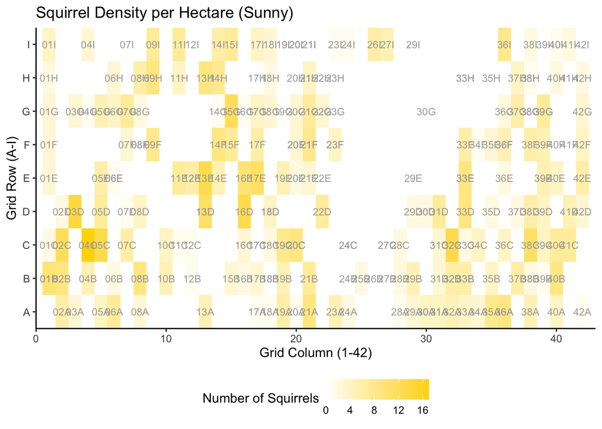

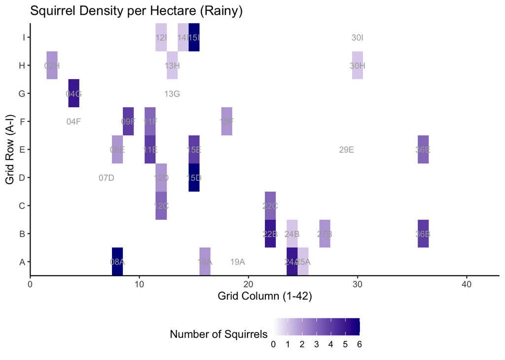

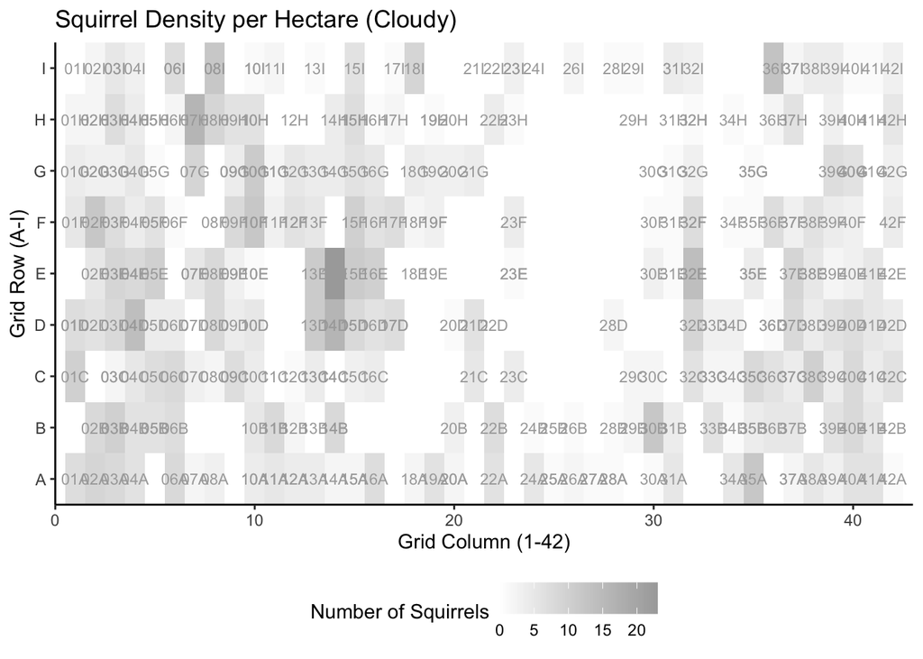

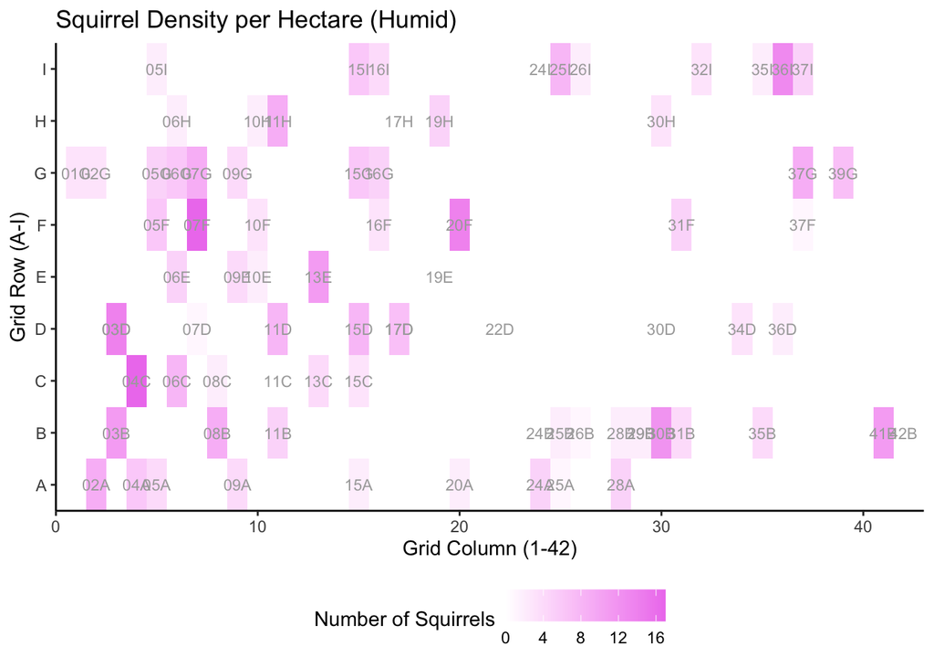

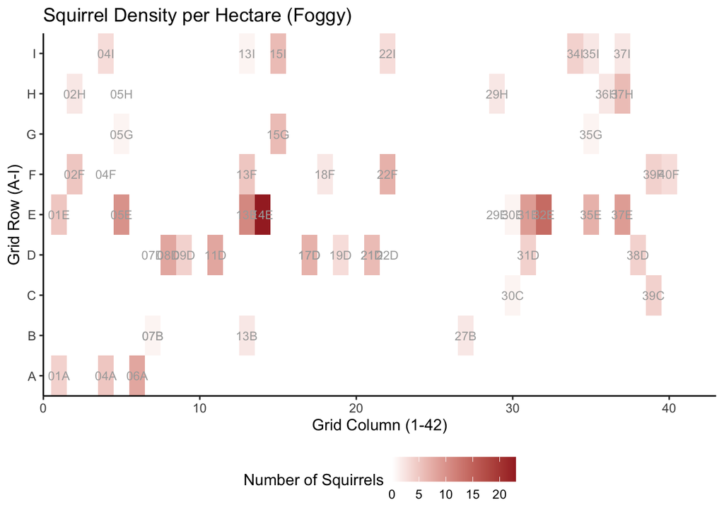

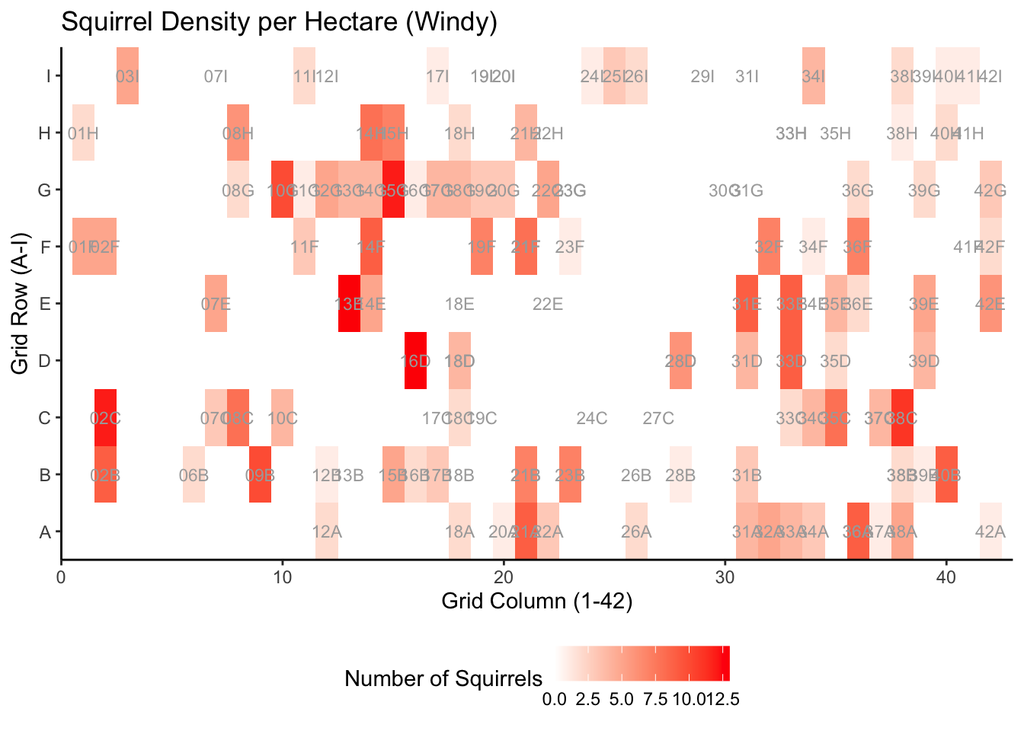

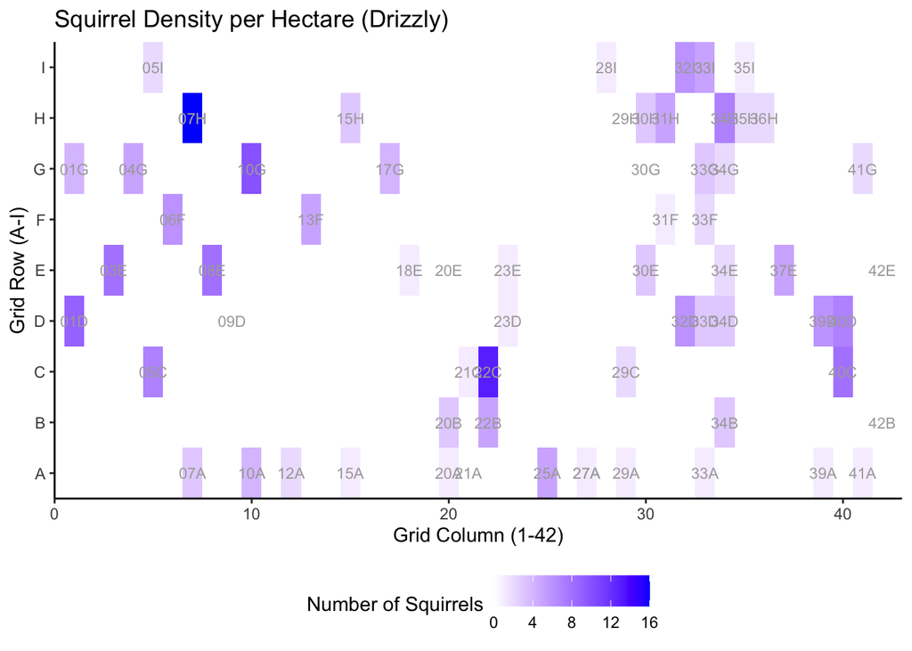

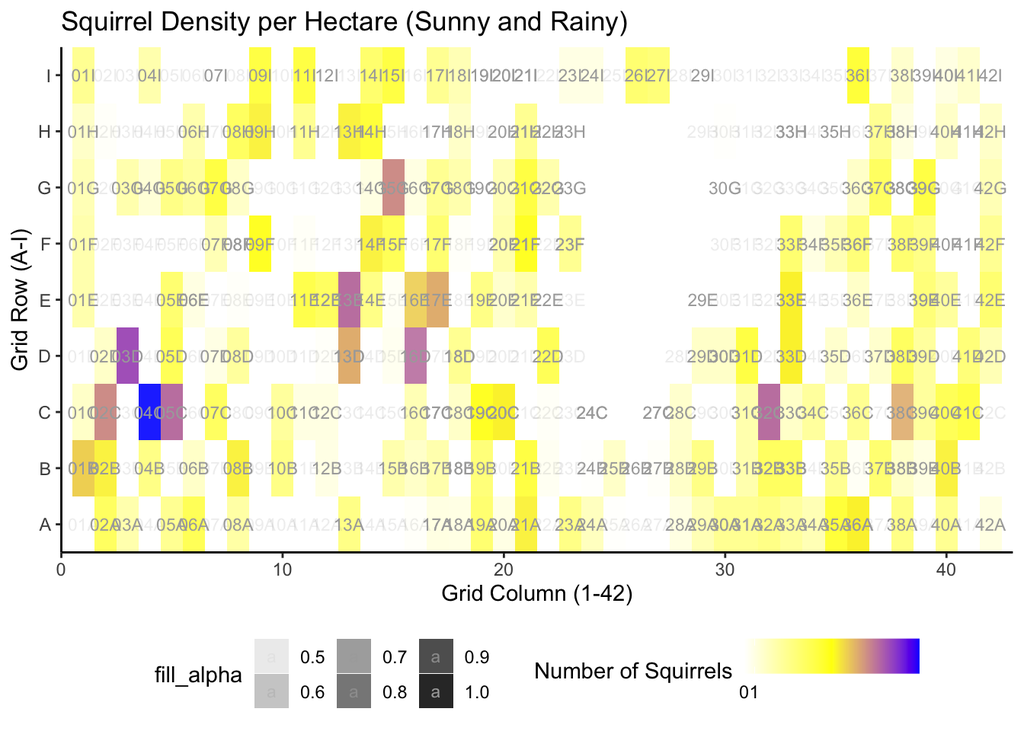

```r
weather_sunny <- subset(weather, sunny == TRUE)

# Plot each subset in a separate plot: heatmap for squirrel sightings when sunny
p_sunny <- ggplot(data = weather_sunny, aes(x = as.numeric(substr(Hectare, 1, 2)),
                                            y = as.factor(substr(Hectare, 3, 3)),
                                            fill = Number.of.Squirrels)) +
  geom_tile() +
  geom_text(aes(label = Hectare), color = "darkgrey", size = 3, vjust = 0.5) +
  scale_fill_gradient(low = "white", high = "gold") +
  scale_x_continuous(limits = c(0, 43), expand = c(0, 0)) +
  scale_y_discrete(limits = c("A", "B", "C", "D", "E", "F", "G", "H", "I"), expand = c(0, 0)) +
  labs(x = "Grid Column (1-42)", y = "Grid Row (A-I)", fill = "Number of Squirrels") +
  theme_classic() +
  ggtitle("Squirrel Density per Hectare (Sunny)") +
  theme(legend.position = "bottom")

p_sunny
```

# 📈 Models

## GLM with date and shift

```r
# Load the necessary packages
library(tidyverse)
# Fit the GLM model
model <- glm(Number.of.Squirrels ~ Date + Shift,
             data = weather,
             family = poisson())


# Summarize the model
summary(model)
```

```
##
## Call:
## glm(formula = Number.of.Squirrels ~ Date + Shift, family = poisson(),
##     data = weather)
##
## Deviance Residuals:
##     Min       1Q   Median       3Q      Max
## -3.1903  -1.5627  -0.3455   0.9024   6.5051
##
## Coefficients:
##               Estimate Std. Error z value Pr(>|z|)
## (Intercept)  1.217e+01  4.279e+00   2.843  0.00446 **
## Date        -1.069e-06  4.228e-07  -2.528  0.01147 *
## ShiftPM      2.155e-01  3.661e-02   5.888 3.92e-09 ***
## ---
## Signif. codes:  0 '***' 0.001 '**' 0.01 '*' 0.05 '.' 0.1 ' ' 1
##
## (Dispersion parameter for poisson family taken to be 1)
##
##     Null deviance: 2120.6  on 699  degrees of freedom
## Residual deviance: 2078.5  on 697  degrees of freedom
## AIC: 4073.8
##
## Number of Fisher Scoring iterations: 5
```

This is a generalized linear model (GLM) with a Poisson family that aims to predict the number of squirrels based on the date and whether the shift is PM or not. The coefficients of the model are estimated using the maximum likelihood method.

The model shows that the number of squirrels decreases as the date increases, while the shift being PM has a positive effect on the number of squirrels. In other words, the model suggests that there are fewer squirrels as time goes by, and that there are more squirrels in the afternoon shift compared to the morning shift.

The significance codes indicate that the intercept, the date, and the shift are all statistically significant predictors of the number of squirrels. The null deviance and residual deviance are measures of the goodness of fit of the model. The AIC provides a measure of the quality of the model relative to other models.

## Overview over the Number of Occurrences of the Different Weather Conditions (and Other Things)

```r
model <- glm(Number.of.Squirrels ~ sunny + drizzly + cloudy + foggy + rainy + humid,
             data = weather,
             family = poisson())

summary(model)
```

```
##
## Call:
## glm(formula = Number.of.Squirrels ~ sunny + drizzly + cloudy +
##     foggy + rainy + humid, family = poisson(), data = weather)
##
## Deviance Residuals:
##     Min       1Q   Median       3Q      Max
## -3.3368  -1.3596  -0.2726   0.8723   5.8774
##
## Coefficients:
##             Estimate Std. Error z value Pr(>|z|)
## (Intercept)  1.50859    0.04212  35.815  < 2e-16 ***
## sunnyTRUE   -0.09541    0.04960  -1.923  0.05442 .
## drizzlyTRUE -0.19733    0.06950  -2.839  0.00452 **
## cloudyTRUE   0.01100    0.04450   0.247  0.80473
## foggyTRUE    0.08026    0.06849   1.172  0.24127
## rainyTRUE   -0.62731    0.11628  -5.395 6.86e-08 ***
## humidTRUE    0.11701    0.05523   2.118  0.03414 *
## ---
## Signif. codes:  0 '***' 0.001 '**' 0.01 '*' 0.05 '.' 0.1 ' ' 1
##
## (Dispersion parameter for poisson family taken to be 1)
##
##     Null deviance: 2120.6  on 699  degrees of freedom
## Residual deviance: 2066.5  on 693  degrees of freedom
## AIC: 4069.7
##
## Number of Fisher Scoring iterations: 5
```

Overall, these results suggest that the number of squirrels observed in Central Park may be influenced by the weather conditions, particularly the presence of rainy, drizzly, and humid weather.

## Linear Regression with Weather Conditions, Shift, Hectare Conditions, and Temperature

```r
# Fit the GLM
model <- glm(Number.of.Squirrels ~ sunny + drizzly + cloudy + foggy + rainy + humid + Shift + Hectare.Conditions + temperature_celsius,
             data = weather,
             family = poisson())

# Summarize the model
summary(model)
```

```
##
## Call:
## glm(formula = Number.of.Squirrels ~ sunny + drizzly + cloudy +
##     foggy + rainy + humid + Shift + Hectare.Conditions + temperature_celsius,
##     family = poisson(), data = weather)
##
## Deviance Residuals:
##     Min       1Q   Median       3Q      Max
## -3.4094  -1.4314  -0.2639   0.8458   6.0024
##
## Coefficients:
##                               Estimate Std. Error z value Pr(>|z|)
## (Intercept)                   1.035508   0.126261   8.201 2.38e-16 ***
## sunnyTRUE                    -0.096519   0.056668  -1.703  0.08852 .
## drizzlyTRUE                  -0.213767   0.077571  -2.756  0.00586 **
## cloudyTRUE                   -0.028087   0.049855  -0.563  0.57317
## foggyTRUE                    -0.001656   0.072606  -0.023  0.98181
## rainyTRUE                    -0.527810   0.130589  -4.042 5.31e-05 ***
## humidTRUE                    -0.030757   0.066034  -0.466  0.64137
## ShiftPM                       0.221908   0.040720   5.450 5.05e-08 ***
## Hectare.ConditionsBusy        0.080011   0.102376   0.782  0.43448
## Hectare.ConditionsCalm        0.253421   0.104174   2.433  0.01499 *
## Hectare.ConditionsCalm, Busy  0.208372   0.152049   1.370  0.17055
## Hectare.ConditionsMedium      0.598377   0.461083   1.298  0.19437
## Hectare.ConditionsModerate    0.185758   0.135837   1.368  0.17147
## temperature_celsius           0.016380   0.003858   4.246 2.18e-05 ***
## ---
## Signif. codes:  0 '***' 0.001 '**' 0.01 '*' 0.05 '.' 0.1 ' ' 1
##
## (Dispersion parameter for poisson family taken to be 1)
##
##     Null deviance: 1877.0  on 623  degrees of freedom
## Residual deviance: 1758.6  on 610  degrees of freedom
##   (76 observations deleted due to missingness)
## AIC: 3579.6
##
## Number of Fisher Scoring iterations: 5
```

The model is a Poisson regression that predicts the number of squirrels seen based on various weather conditions. The variables included in the model are: sunny, drizzly, cloudy, foggy, rainy, humid, Shift (morning or afternoon), Hectare.Conditions (categorical variable with levels: “Calm”, “Busy”, “Moderate”, “Calm, Busy”, and “Medium”), and temperature_celsius.

Overall, the model suggests that temperature and time of day may be the most important factors in predicting the number of squirrels seen. However, it is important to note that the model’s predictions may not be accurate for weather conditions and environments outside of the observed data.

## Regression with Time and Temperature (with Interaction Term)

```r
reg <- glm(Number.of.Squirrels ~ temperature_celsius * Shift, data = weather, family = poisson())
summary(reg)
```

```
##
## Call:
## glm(formula = Number.of.Squirrels ~ temperature_celsius * Shift,
##     family = poisson(), data = weather)
##
## Deviance Residuals:
##     Min       1Q   Median       3Q      Max
## -3.1789  -1.4730  -0.4512   0.8527   6.2938
##
## Coefficients:
##                              Estimate Std. Error z value Pr(>|z|)
## (Intercept)                  0.819493   0.079699  10.282  < 2e-16 ***
## temperature_celsius          0.035106   0.004805   7.306 2.76e-13 ***
## ShiftPM                      0.784268   0.114525   6.848 7.49e-12 ***
## temperature_celsius:ShiftPM -0.035008   0.006612  -5.295 1.19e-07 ***
## ---
## Signif. codes:  0 '***' 0.001 '**' 0.01 '*' 0.05 '.' 0.1 ' ' 1
##
## (Dispersion parameter for poisson family taken to be 1)
##
##     Null deviance: 1877.0  on 623  degrees of freedom
## Residual deviance: 1774.6  on 620  degrees of freedom
##   (76 observations deleted due to missingness)
## AIC: 3575.6
##
## Number of Fisher Scoring iterations: 5
```

Overall, this model suggests that the number of squirrels is influenced by both temperature and shift, with the effect of temperature depending on the time of the shift. Specifically, there is a positive relationship between the number of squirrels and both temperature and shift, but the effect of temperature is stronger in the morning than in the afternoon.

# 🐿️❤️ What does this mean for you, squirrel lover?